# Atividade prática

11 de março de 2024

## Objetivo e instruções

Nesta etapa da aula, veremos a utilidade da visualização de dados no programa R. Durante a disciplina também aprenderemos a confeccionar códigos e gráficos similares a estes.

Etapas:

- Abra o *RStudio* em seu computador;
- Utilize o botão “copy to clipboard” para copiar as partes do código (*chunks*) para a sua área de transferência;
- Cole as partes do código em um *Script* do *RStudio*;
- Posteriormente, daremos continuidade à execução do código.

## Prática 1

O primeiro conteúdo prático refere-se ao uso da ferramenta *Google trends*. Essa ferramenta permite explorar e analisar as tendências de busca na internet ao longo do tempo. Por exemplo, vejamos a tendência de pesquisa, no Brasil.

Vejamos o mecanismo de procura de palavras no [Google trends](https://trends.google.com/trends/). Façam buscas de termos como “sisu”, “enem” ou termos de seu interesse.

### Como buscar e visualizar esses dados no *RStudio*?

Utilizaremos um pacote chamado *gtrendsR*. Esse pacote permite fazer buscas de termos, por país e em períodos específicos, que são inseridos como *parâmetros* da função.

Para começarmos, copie o seguinte código e cole em um novo *script* do *RStudio*.

- **Obs.:** Para criar um novo *script*, selecione a opção (+), situada no canto superior esquerdo do *RStudio*, e selecione *R Script*.

Aguarde e solicite as instruções do docente para executar o código.

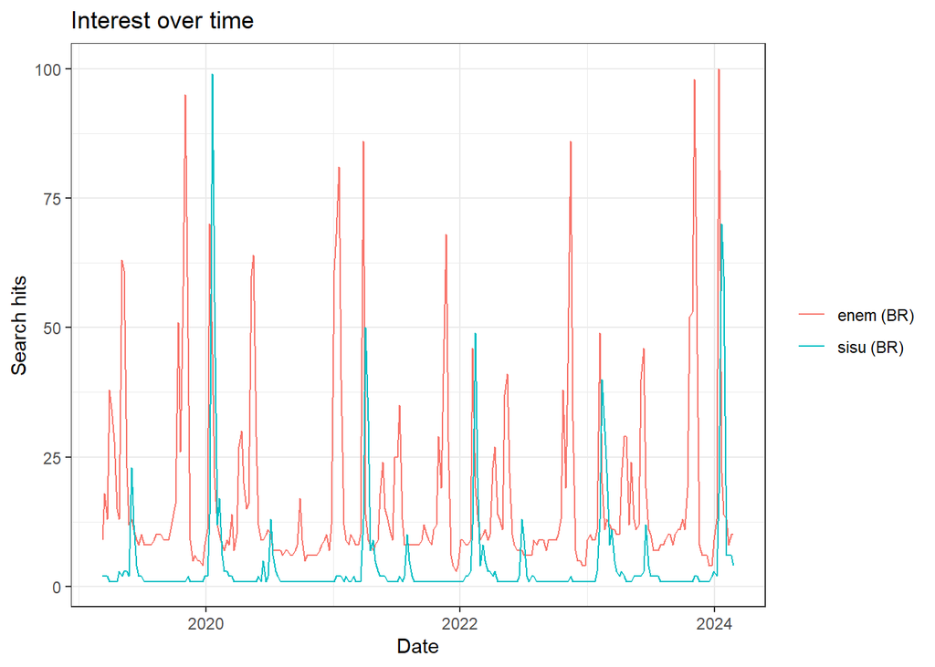

```r
# instalando o pacote gtrendsR em seu computador
if (!requireNamespace("gtrendsR", quietly = TRUE)) {install.packages("gtrendsR")}

# solicitando o pacote na biblioteca
library("gtrendsR")

# fazendo a busca pelos termos sisu e enem no Brasil
termo <- gtrends(c("sisu", "enem"), geo = c("BR"), onlyInterest = T)

# grafico
plot(termo)
```

Esse código construirá um gráfico com o número de pesquisas feitas no Brasil com os termos sisu e enem.

- **Tarefa.:** Vamos buscar novos termos e executar o código. Para isso, devemos substituir a parte `termo <- gtrends(c("sisu", "enem"), geo = c("BR"), onlyInterest = T)` trocando `c("sisu", "enem")` pelo termo de seu interesse. Por exemplo, suponha que desejo buscar o termo *ufla*, então:

```r
# solicitando o pacote na biblioteca
library("gtrendsR")

# PARTE ALTERADA
termo <- gtrends(c("ufla"), geo = c("BR"), onlyInterest = T)

# grafico
plot(termo)
```

## Prática 2

Também podemos estudar informações espaciais no *R*. Uma forma é localizar e apresentar informações em mapas.

Nessa segunda atividade prática, vamos apresentar um mapa com a localização da cidade de Lavras, Minas Gerais, fornecendo as coordenadas (longitude e latitude) no código.

Assim como realizado na atividade prática 1, copie o código abaixo e cole em um novo *script* do *RStudio*.

```r
# instalando o pacote leaflet em seu computador
if (!requireNamespace("leaflet", quietly = TRUE)) {install.packages("leaflet")}

# coordenadas
longitude <- -44.998950
latitude <- -21.229180

# construindo o mapa
library(leaflet)
m <- leaflet() %>%
  addTiles(urlTemplate = 'https://{s}.tile.openstreetmap.org/{z}/{x}/{y}.png') %>%
  setView(lng = longitude, lat = latitude, zoom = 6) %>%
  addMarkers(lng = longitude, lat = latitude)
m
```

[interactive chart not shown]

**Tarefa.:** Vamos adicionar mais uma localidade a esse gráfico. Que tal a localização de sua cidade?

Para isso, precisamos buscar as coordenadas. Uma forma de fazer isso é buscar usando a ferramenta *maps* da *Google*. Inicialmente, acessem [Maps](https://maps.google.com/) e digitem o nome do local de interesse.

**Passos para buscar as coordenadas:**

- Digite o nome do local na ferramenta de busca do *maps*, situada no canto superior esquerdo;
- No mapa gerado, aponte a seta para o local desejado, clique com o botão esquerdo do *mouse* ou do *touchpad* e copie as coordenadas que aparecerão.
- O primeiro termo refere-se à latitude e o segundo é a longitude.

Por exemplo, incluindo as coordenadas (-45.48012; -21.58266) no mapa:

```r
# coordenadas de lavras
longitude <- -44.998950
latitude <- -21.229180

# novas coordenadas
longitude_1 = -45.48012
latitude_1 = -21.58266

# construindo o mapa
library(leaflet)
m <- leaflet() %>%
  addTiles(urlTemplate = 'https://{s}.tile.openstreetmap.org/{z}/{x}/{y}.png') %>%
  setView(lng = longitude, lat = latitude, zoom = 6) %>%
  addMarkers(lng = longitude, lat = latitude) %>%
  addMarkers(lng = longitude_1, lat = latitude_1)
m
```

[interactive chart not shown]

Busquem e reproduzam o mapa substituindo `longitude_1` e `latitude_1` por novas coordenadas. Vamos tentar?